# Optimising approval rates by creating segmented models

Credit risk series (Post #5)

royr2

2023-03-29

Here’s a short post on why one should consider developing a segmented model when building credit risk scorecards to help optimize approval rates. While segmentation offers a variety of benefits, this post aims to offer a different perspective.

I will be reusing code from a previous post. Feel free to navigate to this post for additional information. Note that sample datasets are available for download from [(here)](https://github.com/royr2/blog/blob/main/download/credit_sample.csv)

## Packages

```r
#install.packages("pacman") ## Install if needed
library(pacman)

# p_load automatically installs packages if needed
p_load(dplyr, magrittr, scales, pROC)
```

## Sample data

```r
smple <- read.csv("../../../download/credit_sample.csv")

# Define target
codes <- c("Charged Off", "Does not meet the credit policy. Status:Charged Off")
smple %<>% mutate(bad_flag = ifelse(loan_status %in% codes, 1, 0))

# Some basic data cleaning
smple[is.na(smple)] <- -1
smple %<>%

  # Remove cases where home ownership and payment plan are not reported
  filter(! home_ownership %in% c("", "NONE"),
         pymnt_plan != "") %>%

  # Convert these two variables into factors
  mutate(home_ownership = factor(home_ownership),
         pymnt_plan = factor(pymnt_plan))
```

## Segments

Typically, credit risk scorecards would have segments like `known goods`, `known bads`, `ever chaged off` etc. For simplicity, I will use the available `FICO grade` variable in the dataset to segment `known goods` and `known bads`. For the purposes of this post, let’s focus on the `known goods` customers (mostly because policy filters would remove the known bad customers).

```r
smple %>%
  group_by(grade) %>%
  summarise(total = n(), bads = sum(bad_flag == 1)) %>%
  mutate(event_rate = percent(bads / total))
```

```
## # A tibble: 7 × 4
##   grade total  bads event_rate
##   <chr> <int> <int> <chr>
## 1 A      1882    68 3.6%
## 2 B      3056   239 7.8%
## 3 C      2805   373 13.3%
## 4 D      1435   257 17.9%
## 5 E       590   144 24.4%
## 6 F       182    65 35.7%
## 7 G        49    16 32.7%
```

Since the event rates are significantly higher, let’s keep borrowers who have a `FICO grade` of `"E", "F" & "G"` in the `known bads` bucket and rest in the `known goods` bucket.

```r
smple %<>%
  mutate(segment = ifelse(grade %in% c("E", "F", "G"), "KB", "KG"))

smple %>%
  group_by(segment) %>%
  tally()
```

```
## # A tibble: 2 × 2
##   segment     n
##   <chr>   <int>
## 1 KB        821
## 2 KG       9178
```

## Model training

Let’s train two separate sets models like so:

- One to the entire population
- And one model to the `known goods`

```r
# Create a formula object to be used across models
form <- as.formula(
  "bad_flag ~
    mths_since_last_delinq +
    total_pymnt +
    acc_now_delinq +
    inq_last_6mths +
    delinq_amnt +
    mths_since_last_record +
    mths_since_recent_revol_delinq +
    mths_since_last_major_derog +
    mths_since_recent_inq +
    mths_since_recent_bc +
    num_accts_ever_120_pd"
)
```

### Model on the entire population

```r
set.seed(1234)

# Train Test split
idx <- sample(1:nrow(smple), size = 0.7 * nrow(smple), replace = F)
train <- smple[idx,]
test <- smple[-idx,]

# Using a GLM model for simplicity
mdl_pop <- glm(
  formula = form,
  family = "binomial",
  data = train
)
```

```r
# Get performance on entire sample
auc(test$bad_flag, predict(mdl_pop, test))
## Setting levels: control = 0, case = 1
## Setting direction: controls < cases
## Area under the curve: 0.6602
```

Now that we have a model, let’s assume an `expected default propensity` target of `2%`. That is to say I can only approve those customers who I believe have an expected default propensity of `2%` or less. Given this, what would be my expected `approval rate`? Note that I need to maximise my approval rate (to better utilise my applicant funnel).

```r
# Output scaling function
scaling_func <- function(vec, PDO = 30, OddsAtAnchor = 5, Anchor = 700){
  beta <- PDO / log(2)
  alpha <- Anchor - PDO * OddsAtAnchor

  # Simple linear scaling of the log odds
  scr <- alpha - beta * vec

  # Round off
  return(round(scr, 0))
}
```

```r
# Find the number of customers that can be approved such that
# the cumulative bad rate is <= target
smple %>%
  filter(segment == "KG") %>%  ## Filter on known goods only
  mutate(pred = predict(mdl_pop, newdata = .),   ## Generate predictions
         score = scaling_func(pred),  ## Scale output
         total = n()) %>%
  arrange(pred) %>%
  mutate(rn = row_number(),
         c_bad_rate = cumsum(bad_flag)/rn) %>%
  filter(c_bad_rate <= 0.02) %>%
  summarise(approve_count = n(),
            total = mean(total),
            score_cutoff = min(score),
            bad_rate = sum(bad_flag)/n()) %>%
  mutate(approval_rate = approve_count / total)
```

```
##   approve_count total score_cutoff   bad_rate approval_rate
## 1           818  9178          689 0.01833741    0.08912617
```

Based on the `unsegmented` model, if we choose a score cutoff of `>=689`, we should expect a bad rate of `~2%` at an approval rate of `~9%`.

### Model on the known good population

```r
set.seed(1234)

# Filter on KG
sample_kg <- smple %>% filter(segment == "KG")
idx <- sample(1:nrow(sample_kg), size = 0.7 * nrow(sample_kg), replace = F)
train <- sample_kg[idx,]
test <- sample_kg[-idx,]

mdl_kg <- glm(
  formula = form,
  family = "binomial",
  data = train
)
```

```r
# Get performance on entire sample
auc(test$bad_flag, predict(mdl_kg, test))
## Setting levels: control = 0, case = 1
## Setting direction: controls < cases
## Area under the curve: 0.6496
```

## Simulations

To evaluate the through the door population better, let’s run some simulations. Let’s assume that only `known good` customers will be assessed through the risk scorecard.

```r
# Function to generate simulations
generate_sim <- function(mdl, nSim = 500, sample_size = 5000, cutoff = 650){

  # Vectors to store output
  bad_rates <- c()
  approval_rates <- c()

  for(i in 1:nSim){

    out <- smple %>%

      # Filter on KG segment
      filter(segment == "KG") %>%

      # Randomly sample with replacement
      sample_n(sample_size, replace = T) %>%

      # Generate model output
      mutate(pred = predict(mdl, newdata = .),
             score = scaling_func(pred)) %>%
      filter(score >= cutoff) %>%
      summarise(bad_rate = sum(bad_flag)/n(), app_rate = n() / sample_size)

    # Store output
    bad_rates[i] <- out$bad_rate
    approval_rates[i] <- out$app_rate
  }

  # Plot output
  par(mfrow = c(1, 2))
  plot(density(bad_rates), main = "Event Rate")
  abline(v = mean(bad_rates))

  plot(density(approval_rates), main = "Approval Rate")
  abline(v = mean(approval_rates))
  par(mfrow = c(1, 1))
}
```

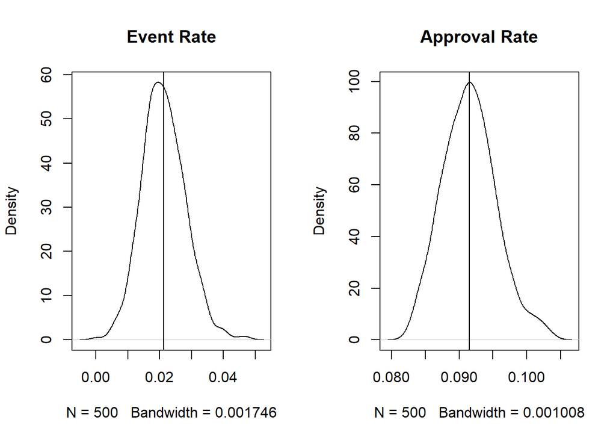

```r
# Simulate using the model built on the entire population
generate_sim(mdl_pop, cutoff = 689)
```

Based on the above simulations, when using the model trained on the entire population and using a threshold of `>=689` the average simulated event rates and approval rates are close to the expected rates from before. But what if we use the model developed only on the `known good population`?

```r
smple %>%
  filter(segment == "KG") %>%  ## Filter on known goods only
  mutate(pred = predict(mdl_kg, newdata = .),   ## Generate predictions
         score = scaling_func(pred),  ## Scale output
         total = n()) %>%
  arrange(pred) %>%
  mutate(rn = row_number(),
         c_bad_rate = cumsum(bad_flag)/rn) %>%
  filter(c_bad_rate <= 0.02) %>%
  summarise(approve_count = n(),
            total = mean(total),
            score_cutoff = min(score),
            bad_rate = sum(bad_flag)/n()) %>%
  mutate(approval_rate = approve_count / total)
```

```
##   approve_count total score_cutoff  bad_rate approval_rate
## 1           904  9178          696 0.0199115     0.0984964
```

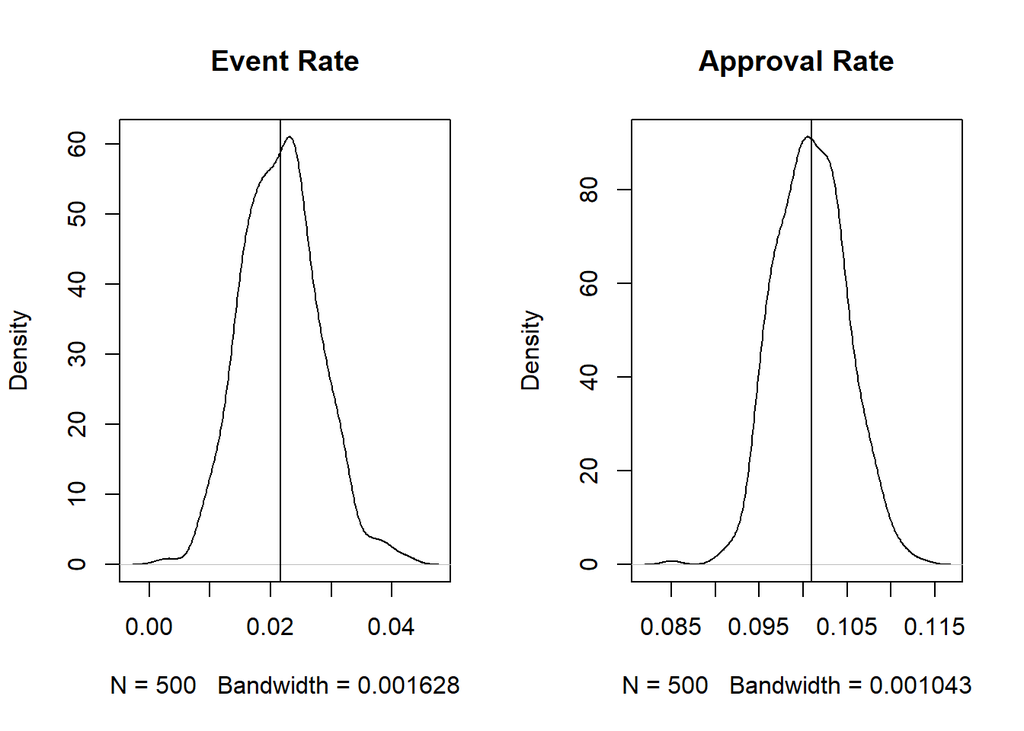

```r
# Simulate using the model built only on the known good population
generate_sim(mdl_kg, cutoff = 696)
```

When using the known-good model, we can achieve a slightly higher approval rate keeping the event rate more or less the same. While the difference is not significant, a ~1% higher approval rate on a large funnel could be significant (psst. monthly targets anyone?).

While most modelers/data scientists understand this, explaining the need to build segmented models to a business owner can be easier if the impact can be linked to business outcomes :wink:.

*Thoughts? Comments? Helpful? Not helpful? Like to see anything else added in here? Let me know!*